# 1US0 TYR Ring_0_0.2_10_Difference

## Sample=1us0-a:39:cd1-a:39:cg-a:39:cd2

| pdb_code | central atom | ca density | parallel atom | pa density | planar atom | pl density |
| --- | --- | --- | --- | --- | --- | --- |
| 1us0 | [14.84, -3.41, 38.3] | 4.0249 | [14.02, -2.84, 37.31] | 0.3957 | [14.64, -2.45, 36.13] | 4.9925 |

## 3d view of density

xyz

yzx

zxy

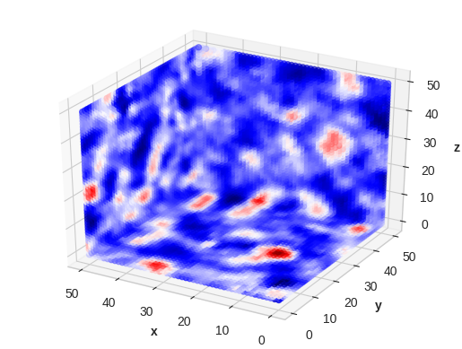

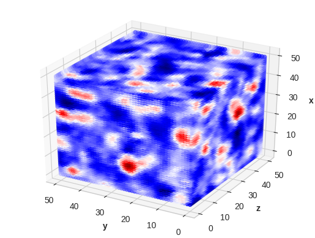

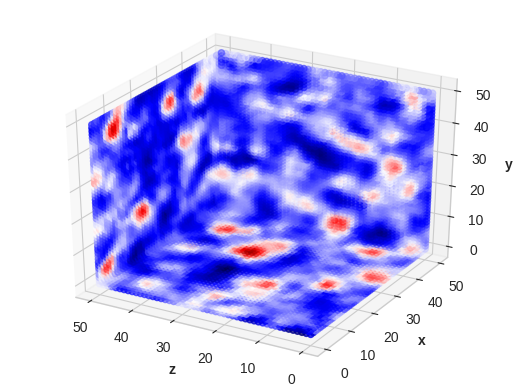

## Histograms of densities

Matrix Histogram

Entire Density Histogram

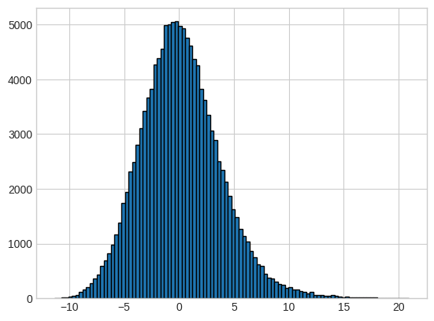

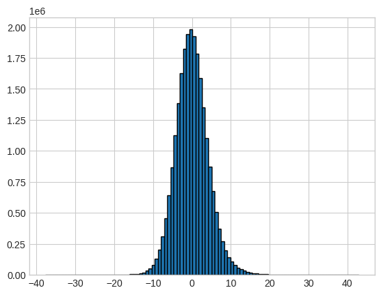

## Slices along x,y and z

Sliced x-wise

Sliced y-wise

Sliced z-wise

0/51

0/51

0/51

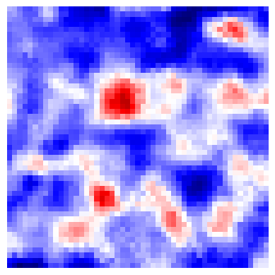

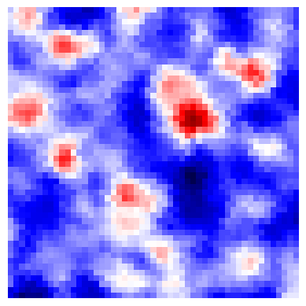

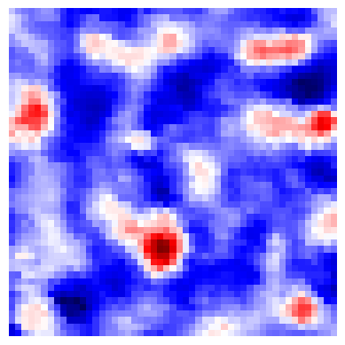

1/51

1/51

1/51

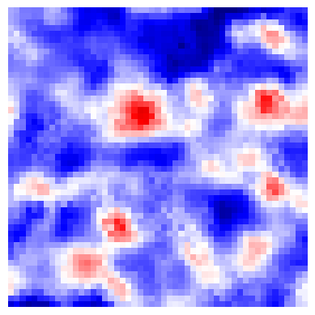

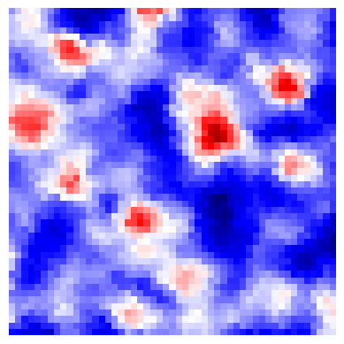

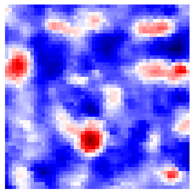

2/51

2/51

2/51

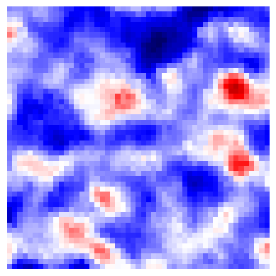

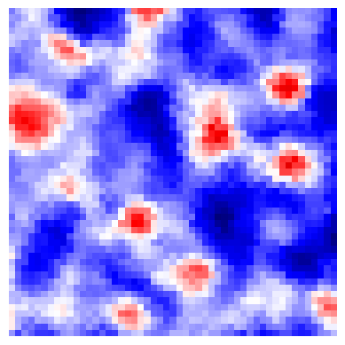

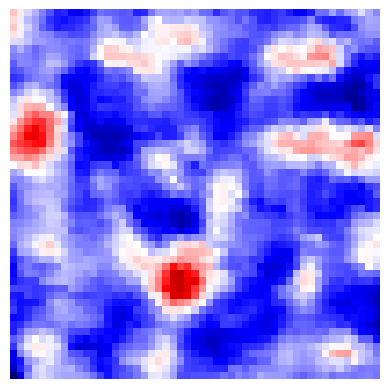

3/51

3/51

3/51

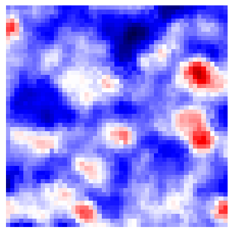

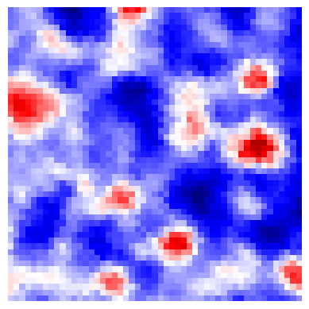

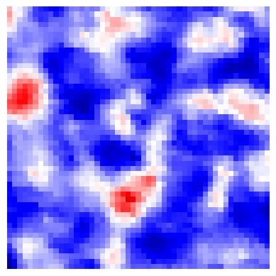

4/51

4/51

4/51

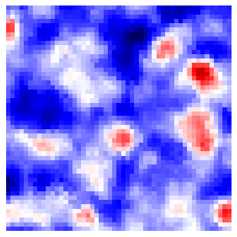

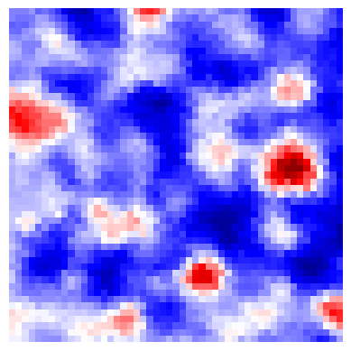

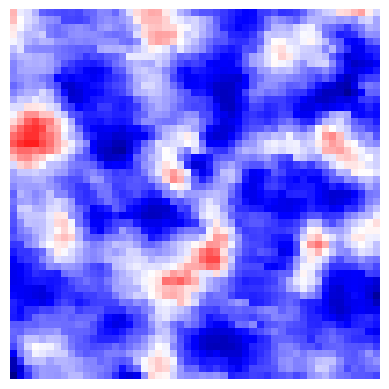

5/51

5/51

5/51

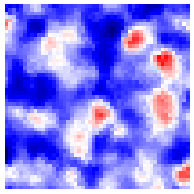

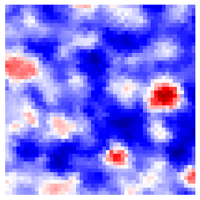

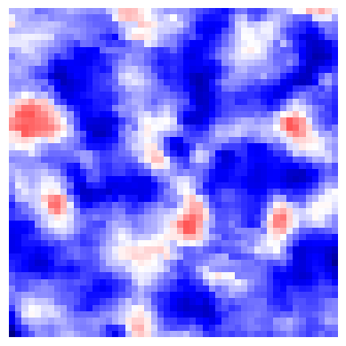

6/51

6/51

6/51

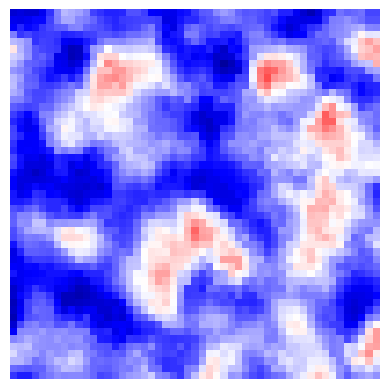

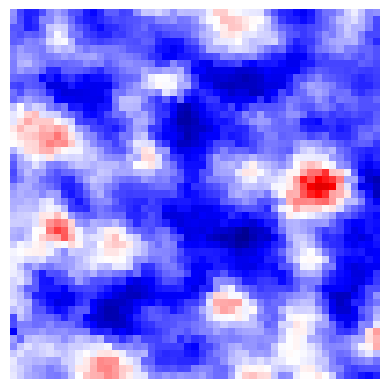

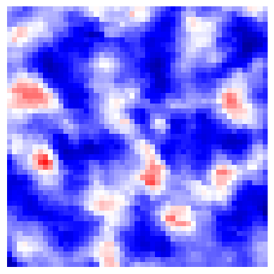

7/51

7/51

7/51

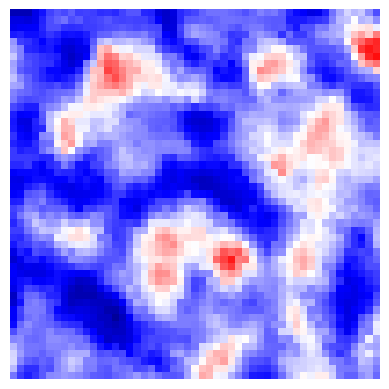

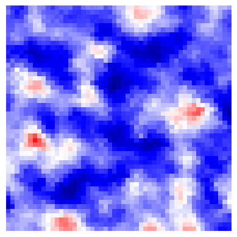

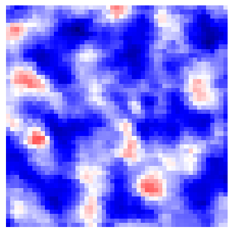

8/51

8/51

8/51

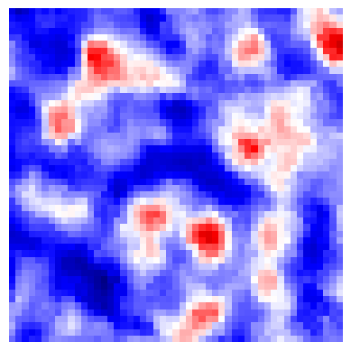

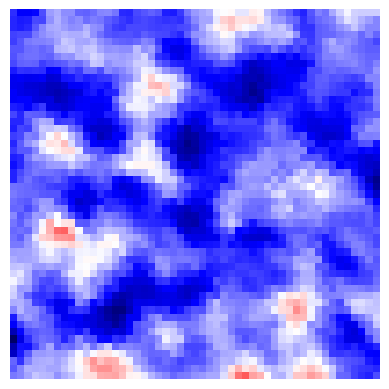

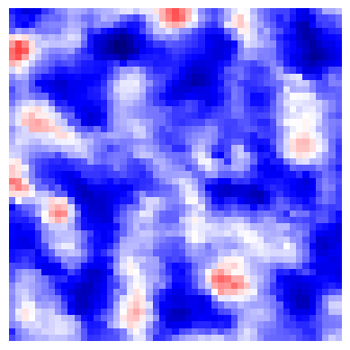

9/51

9/51

9/51

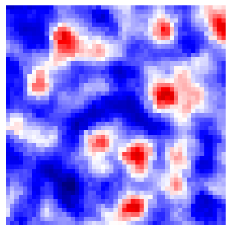

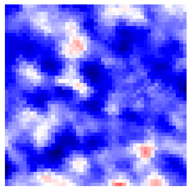

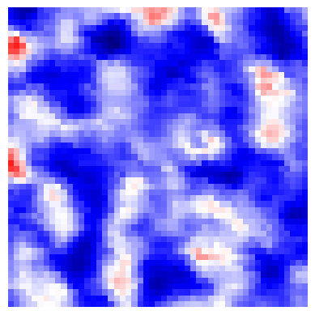

10/51

10/51

10/51

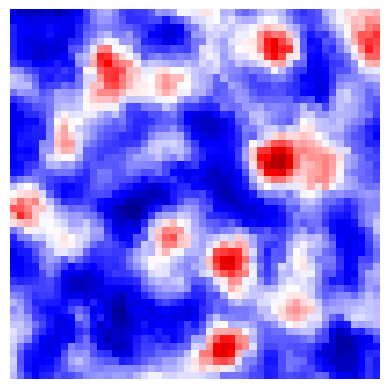

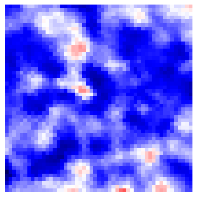

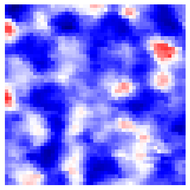

11/51

11/51